# SL - Project_ Ramakrishnan P

```python
#Importing all the necessary libraries

import numpy as np
import pandas as pd
import matplotlib.pyplot as plt
%matplotlib inline
import seaborn as sns
from sklearn import preprocessing
from sklearn.model_selection import train_test_split, cross_val_score
from sklearn import metrics
from sklearn.neighbors import KNeighborsClassifier
from scipy.stats import zscore
from sklearn.metrics import classification_report, confusion_matrix
```

## 1. Import and warehouse data:

• Import all the given datasets and explore shape and size of each.

• Merge all datasets onto one and explore final shape and size.

```python
#Reading the files

normal = pd.read_csv('Part1 - Normal.csv')
type_h = pd.read_csv('Part1 - Type_H.csv')
type_s = pd.read_csv('Part1 - Type_S.csv')
```

Printing the first and last 5 rows of all the 3 files

Checking for null values, shape, size and datatypes

```python
normal.head()
```

|  | P_incidence | P_tilt | L_angle | S_slope | P_radius | S_Degree | Class |
| --- | --- | --- | --- | --- | --- | --- | --- |
| 0 | 38.505273 | 16.964297 | 35.112814 | 21.540976 | 127.632875 | 7.986683 | Normal |
| 1 | 54.920858 | 18.968430 | 51.601455 | 35.952428 | 125.846646 | 2.001642 | Normal |
| 2 | 44.362490 | 8.945435 | 46.902096 | 35.417055 | 129.220682 | 4.994195 | Normal |
| 3 | 48.318931 | 17.452121 | 48.000000 | 30.866809 | 128.980308 | -0.910941 | Normal |
| 4 | 45.701789 | 10.659859 | 42.577846 | 35.041929 | 130.178314 | -3.388910 | Normal |

```python
normal.tail()
```

|  | P_incidence | P_tilt | L_angle | S_slope | P_radius | S_Degree | Class |
| --- | --- | --- | --- | --- | --- | --- | --- |
| 95 | 47.903565 | 13.616688 | 36.000000 | 34.286877 | 117.449062 | -4.245395 | Normal |
| 96 | 53.936748 | 20.721496 | 29.220534 | 33.215251 | 114.365845 | -0.421010 | Normal |
| 97 | 61.446597 | 22.694968 | 46.170347 | 38.751628 | 125.670725 | -2.707880 | Normal |
| 98 | 45.252792 | 8.693157 | 41.583126 | 36.559635 | 118.545842 | 0.214750 | Normal |
| 99 | 33.841641 | 5.073991 | 36.641233 | 28.767649 | 123.945244 | -0.199249 | Normal |

```python
normal.isna().sum()
```

```
P_incidence    0
P_tilt         0
L_angle        0
S_slope        0
P_radius       0
S_Degree       0
Class          0
dtype: int64
```

```python
normal.dtypes
```

```
P_incidence    float64
P_tilt         float64
L_angle        float64
S_slope        float64
P_radius       float64
S_Degree       float64
Class           object
dtype: object
```

```python
normal.shape
```

```
(100, 7)
```

```python
normal.size
```

```
700
```

```python
type_h.head()
```

|  | P_incidence | P_tilt | L_angle | S_slope | P_radius | S_Degree | Class |
| --- | --- | --- | --- | --- | --- | --- | --- |
| 0 | 63.027818 | 22.552586 | 39.609117 | 40.475232 | 98.672917 | -0.254400 | Type_H |
| 1 | 39.056951 | 10.060991 | 25.015378 | 28.995960 | 114.405425 | 4.564259 | Type_H |
| 2 | 68.832021 | 22.218482 | 50.092194 | 46.613539 | 105.985135 | -3.530317 | Type_H |
| 3 | 69.297008 | 24.652878 | 44.311238 | 44.644130 | 101.868495 | 11.211523 | Type_H |
| 4 | 49.712859 | 9.652075 | 28.317406 | 40.060784 | 108.168725 | 7.918501 | Type_H |

```python
type_h.tail()
```

|  | P_incidence | P_tilt | L_angle | S_slope | P_radius | S_Degree | Class |
| --- | --- | --- | --- | --- | --- | --- | --- |
| 55 | 47.657730 | 13.277385 | 36.679985 | 34.380345 | 98.249781 | 6.273012 | Type_H |
| 56 | 43.349606 | 7.467469 | 28.065483 | 35.882137 | 112.776187 | 5.753277 | Type_H |
| 57 | 46.855781 | 15.351514 | 38.000000 | 31.504267 | 116.250917 | 1.662706 | Type_H |
| 58 | 43.203185 | 19.663146 | 35.000000 | 23.540039 | 124.846109 | -2.919076 | Type_H |
| 59 | 48.109236 | 14.930725 | 35.564683 | 33.178512 | 124.056452 | 7.947905 | Type_H |

```python
type_h.isna().sum()
```

```
P_incidence    0
P_tilt         0
L_angle        0
S_slope        0
P_radius       0
S_Degree       0
Class          0
dtype: int64
```

```python
type_h.dtypes
```

```
P_incidence    float64
P_tilt         float64
L_angle        float64
S_slope        float64
P_radius       float64
S_Degree       float64
Class           object
dtype: object
```

```python
type_h.shape
```

```
(60, 7)
```

```python
type_h.size
```

```
420
```

```python
type_s.head()
```

|  | P_incidence | P_tilt | L_angle | S_slope | P_radius | S_Degree | Class |
| --- | --- | --- | --- | --- | --- | --- | --- |
| 0 | 74.377678 | 32.053104 | 78.772013 | 42.324573 | 143.560690 | 56.125906 | Type_S |
| 1 | 89.680567 | 32.704435 | 83.130732 | 56.976132 | 129.955476 | 92.027277 | Type_S |
| 2 | 44.529051 | 9.433234 | 52.000000 | 35.095817 | 134.711772 | 29.106575 | Type_S |
| 3 | 77.690577 | 21.380645 | 64.429442 | 56.309932 | 114.818751 | 26.931841 | Type_S |
| 4 | 76.147212 | 21.936186 | 82.961502 | 54.211027 | 123.932010 | 10.431972 | Type_S |

```python
type_s.tail()
```

|  | P_incidence | P_tilt | L_angle | S_slope | P_radius | S_Degree | Class |
| --- | --- | --- | --- | --- | --- | --- | --- |
| 145 | 80.111572 | 33.942432 | 85.101608 | 46.169139 | 125.593624 | 100.292107 | Type_S |
| 146 | 95.480229 | 46.550053 | 59.000000 | 48.930176 | 96.683903 | 77.283072 | Type_S |
| 147 | 74.094731 | 18.823727 | 76.032156 | 55.271004 | 128.405731 | 73.388216 | Type_S |
| 148 | 87.679087 | 20.365613 | 93.822416 | 67.313473 | 120.944829 | 76.730629 | Type_S |
| 149 | 48.259920 | 16.417462 | 36.329137 | 31.842457 | 94.882336 | 28.343799 | Type_S |

```python
type_s.isna().sum()
```

```
P_incidence    0
P_tilt         0
L_angle        0
S_slope        0
P_radius       0
S_Degree       0
Class          0
dtype: int64
```

```python
type_s.dtypes
```

```
P_incidence    float64
P_tilt         float64
L_angle        float64
S_slope        float64
P_radius       float64
S_Degree       float64
Class           object
dtype: object
```

```python
type_s.shape
```

```
(150, 7)
```

```python
type_s.size
```

```
1050
```

Merging all datasets into one and confirming its shape, size

Printing the top 5 rows

```python
df = pd.concat([normal, type_h, type_s])
```

```python
df.head()
```

|  | P_incidence | P_tilt | L_angle | S_slope | P_radius | S_Degree | Class |
| --- | --- | --- | --- | --- | --- | --- | --- |
| 0 | 38.505273 | 16.964297 | 35.112814 | 21.540976 | 127.632875 | 7.986683 | Normal |
| 1 | 54.920858 | 18.968430 | 51.601455 | 35.952428 | 125.846646 | 2.001642 | Normal |
| 2 | 44.362490 | 8.945435 | 46.902096 | 35.417055 | 129.220682 | 4.994195 | Normal |
| 3 | 48.318931 | 17.452121 | 48.000000 | 30.866809 | 128.980308 | -0.910941 | Normal |
| 4 | 45.701789 | 10.659859 | 42.577846 | 35.041929 | 130.178314 | -3.388910 | Normal |

```python
df.shape
```

```
(310, 7)
```

```python
df.size
```

```
2170
```

## 2. Data cleansing:

• Explore and if required correct the datatypes of each attribute

• Explore for null values in the attributes and if required drop or impute values.

Checking for datatypes of merged dataset

Checking the unique values of column 'Class'

```python
df.dtypes
```

```
P_incidence    float64
P_tilt         float64
L_angle        float64
S_slope        float64
P_radius       float64
S_Degree       float64
Class           object
dtype: object
```

```python
df['Class'].unique()
```

```
array(['Normal', 'Nrmal', 'Type_H', 'type_h', 'Type_S', 'tp_s'],
      dtype=object)
```

Replacing the wrong values of column 'Class' with the right ones

```python
df['Class'] = df['Class'].replace(['Nrmal'],'Normal')
```

```python
df['Class'] = df['Class'].replace(['type_h'],'Type_H')
```

```python
df['Class'] = df['Class'].replace(['tp_s'],'Type_S')
```

```python
df['Class'].unique()
```

```
array(['Normal', 'Type_H', 'Type_S'], dtype=object)
```

Changing the datatype of column 'Class' to category

```python
df['Class'] = df['Class'].astype('category')
```

Checking the datatype and presence of null values in merged dataset

```python
df.dtypes
```

```
P_incidence     float64
P_tilt          float64
L_angle         float64
S_slope         float64
P_radius        float64
S_Degree        float64
Class          category
dtype: object
```

```python
df.isna().sum()
```

```
P_incidence    0
P_tilt         0
L_angle        0
S_slope        0
P_radius       0
S_Degree       0
Class          0
dtype: int64
```

## 3. Data analysis & visualisation:

• Perform detailed statistical analysis on the data.

• Perform a detailed univariate, bivariate and multivariate analysis with appropriate detailed comments after each analysis.

'describe' function gives a brief about the statistics of the dataframe

```python
df.describe()
```

|  | P_incidence | P_tilt | L_angle | S_slope | P_radius | S_Degree |
| --- | --- | --- | --- | --- | --- | --- |
| count | 310.000000 | 310.000000 | 310.000000 | 310.000000 | 310.000000 | 310.000000 |
| mean | 60.496653 | 17.542822 | 51.930930 | 42.953831 | 117.920655 | 26.296694 |
| std | 17.236520 | 10.008330 | 18.554064 | 13.423102 | 13.317377 | 37.559027 |
| min | 26.147921 | -6.554948 | 14.000000 | 13.366931 | 70.082575 | -11.058179 |
| 25% | 46.430294 | 10.667069 | 37.000000 | 33.347122 | 110.709196 | 1.603727 |
| 50% | 58.691038 | 16.357689 | 49.562398 | 42.404912 | 118.268178 | 11.767934 |
| 75% | 72.877696 | 22.120395 | 63.000000 | 52.695888 | 125.467674 | 41.287352 |
| max | 129.834041 | 49.431864 | 125.742385 | 121.429566 | 163.071041 | 418.543082 |

'corr' function shows the correlation between the data variables

```python
df.corr()
```

|  | P_incidence | P_tilt | L_angle | S_slope | P_radius | S_Degree |
| --- | --- | --- | --- | --- | --- | --- |
| P_incidence | 1.000000 | 0.629199 | 0.717282 | 0.814960 | -0.247467 | 0.638743 |
| P_tilt | 0.629199 | 1.000000 | 0.432764 | 0.062345 | 0.032668 | 0.397862 |
| L_angle | 0.717282 | 0.432764 | 1.000000 | 0.598387 | -0.080344 | 0.533667 |
| S_slope | 0.814960 | 0.062345 | 0.598387 | 1.000000 | -0.342128 | 0.523557 |
| P_radius | -0.247467 | 0.032668 | -0.080344 | -0.342128 | 1.000000 | -0.026065 |
| S_Degree | 0.638743 | 0.397862 | 0.533667 | 0.523557 | -0.026065 | 1.000000 |

Correlation matrix plotting using heatmap

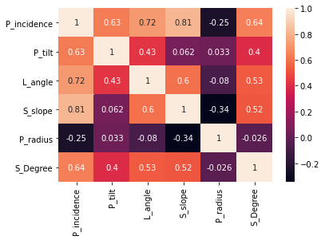

```python
sns.heatmap(df.corr(),annot=True)
```

Pair plot of the data variables gives a better idea of the correlation data

Here 'Class' is selected as hue as it is the categorical data

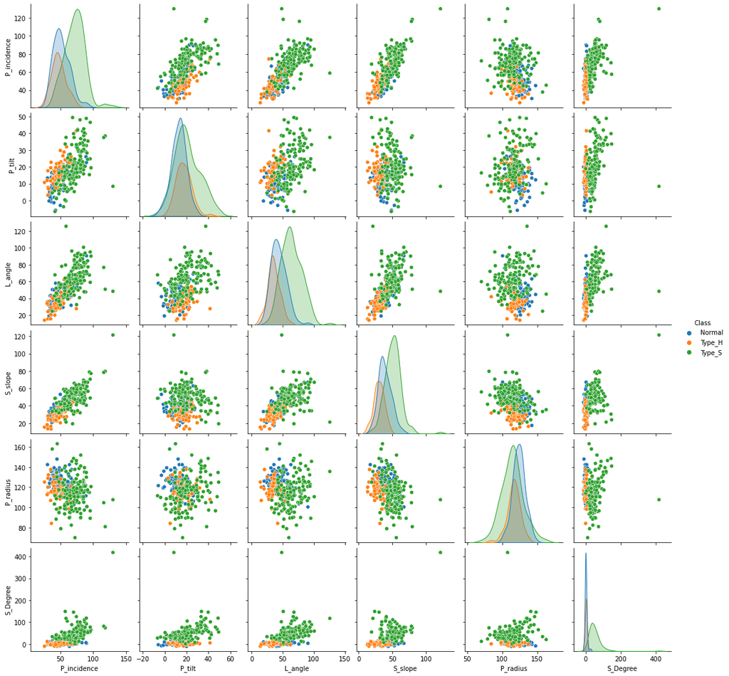

```python
sns.pairplot(df, hue='Class')
```

'P_incidence', 'L_angle' and 'S_slope' are having positive correlation between one another which are seen in the multi-variate analysis

Same are depicted below in the form of bivariate analysis

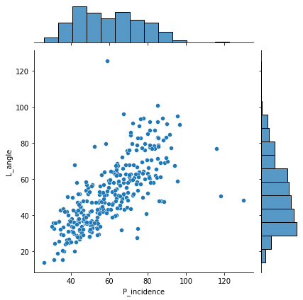

```python
sns.jointplot(df['P_incidence'], df['L_angle']);
```

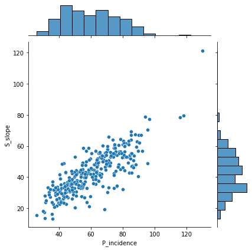

```python
sns.jointplot(df['P_incidence'], df['S_slope']);
```

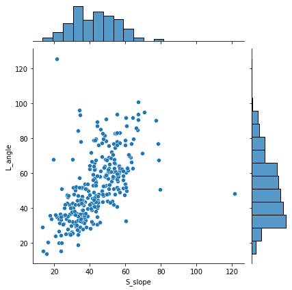

```python
sns.jointplot(df['S_slope'], df['L_angle']);
```

Swarm plots are plotted to get an understanding of the distribution of each data variables with respect to 'Class'

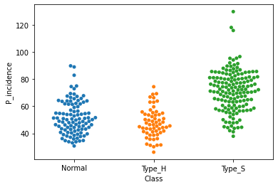

```python
sns.swarmplot(df['Class'], df['P_incidence']);
```

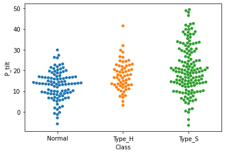

```python
sns.swarmplot(df['Class'], df['P_tilt']);
```

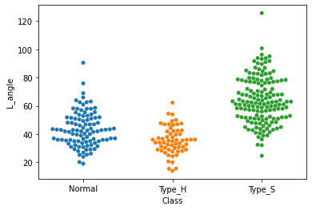

```python
sns.swarmplot(df['Class'], df['L_angle']);
```

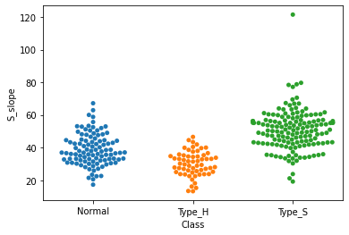

```python
sns.swarmplot(df['Class'], df['S_slope']);
```

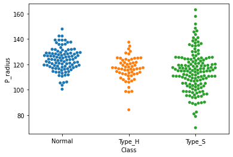

```python
sns.swarmplot(df['Class'], df['P_radius']);
```

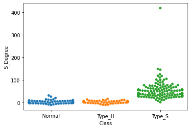

```python
sns.swarmplot(df['Class'], df['S_Degree']);
```

## 4. Data pre-processing:

• Segregate predictors vs target attributes

• Perform normalisation or scaling if required.

• Check for target balancing. Add your comments.

• Perform train-test split.

```python
#Segregation of predictors and target attributes

X = df.drop(labels= 'Class' , axis = 1)
y = df['Class']
```

```python
X.head()
```

|  | P_incidence | P_tilt | L_angle | S_slope | P_radius | S_Degree |
| --- | --- | --- | --- | --- | --- | --- |
| 0 | 38.505273 | 16.964297 | 35.112814 | 21.540976 | 127.632875 | 7.986683 |
| 1 | 54.920858 | 18.968430 | 51.601455 | 35.952428 | 125.846646 | 2.001642 |
| 2 | 44.362490 | 8.945435 | 46.902096 | 35.417055 | 129.220682 | 4.994195 |
| 3 | 48.318931 | 17.452121 | 48.000000 | 30.866809 | 128.980308 | -0.910941 |
| 4 | 45.701789 | 10.659859 | 42.577846 | 35.041929 | 130.178314 | -3.388910 |

```python
y.unique()
```

```
[Normal, Type_H, Type_S]
Categories (3, object): [Normal, Type_H, Type_S]
```

```python
#Noramlising or scaling of data

XScaled  = X.apply(zscore)  # convert all attributes to Z scale

XScaled.describe()
```

|  | P_incidence | P_tilt | L_angle | S_slope | P_radius | S_Degree |
| --- | --- | --- | --- | --- | --- | --- |
| count | 3.100000e+02 | 3.100000e+02 | 3.100000e+02 | 3.100000e+02 | 3.100000e+02 | 3.100000e+02 |
| mean | 8.702716e-17 | 2.326096e-16 | 1.980495e-16 | 5.121351e-17 | -6.274551e-16 | -8.156558e-17 |
| std | 1.001617e+00 | 1.001617e+00 | 1.001617e+00 | 1.001617e+00 | 1.001617e+00 | 1.001617e+00 |
| min | -1.996010e+00 | -2.411664e+00 | -2.047652e+00 | -2.207741e+00 | -3.597963e+00 | -9.961725e-01 |
| 25% | -8.173982e-01 | -6.881138e-01 | -8.060267e-01 | -7.168418e-01 | -5.423830e-01 | -6.585073e-01 |
| 50% | -1.049246e-01 | -1.186061e-01 | -1.278621e-01 | -4.095971e-02 | 2.613767e-02 | -3.874502e-01 |
| 75% | 7.194643e-01 | 4.581158e-01 | 5.975493e-01 | 7.269414e-01 | 5.676209e-01 | 3.997679e-01 |
| max | 4.029206e+00 | 3.191402e+00 | 3.984615e+00 | 5.855771e+00 | 3.395818e+00 | 1.046035e+01 |

```python
#Split X and y into training and test set in 70:30 ratio

X_train, X_test, y_train, y_test = train_test_split(XScaled, y, test_size=0.30, random_state=1)
```

## 5. Model training, testing and tuning:

• Design and train a KNN classifier.

• Display the classification accuracies for train and test data.

• Display and explain the classification report in detail.

• Automate the task of finding best values of K for KNN.

• Apply all the possible tuning techniques to train the best model for the given data. Select the final best trained model with your comments for selecting this model.

```python
NNH = KNeighborsClassifier(n_neighbors=5 , weights = 'distance' )
```

```python
# Call Nearest Neighbour algorithm

NNH.fit(X_train, y_train)
```

```
KNeighborsClassifier(weights='distance')
```

```python
# Accuracy of training data

predicted_labels = NNH.predict(X_train)
NNH.score(X_train, y_train)
```

```
1.0
```

```python
# Accuracy of testing data

predicted_labels = NNH.predict(X_test)
NNH.score(X_test, y_test)
```

```
0.7526881720430108
```

```python
# Confusion matrix

print(confusion_matrix(y_test, predicted_labels))
```

```
[[17  7  4]
 [ 6 11  0]
 [ 4  2 42]]
```

```
Confusion Matrix
```

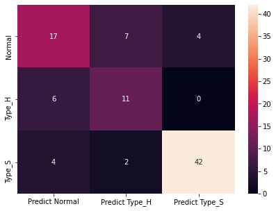

```python
# calculate accuracy measures and confusion matrix. Printing the same as heatmap
from sklearn import metrics

print("Confusion Matrix")
cm=metrics.confusion_matrix(y_test, predicted_labels, labels=['Normal', 'Type_H', 'Type_S'])

df_cm = pd.DataFrame(cm, index = [i for i in ['Normal', 'Type_H', 'Type_S']],
                  columns = [i for i in ['Predict Normal', 'Predict Type_H', 'Predict Type_S']])
plt.figure(figsize = (7,5))
sns.heatmap(df_cm, annot=True)
```

```python
print(classification_report(y_test, predicted_labels))
```

```
              precision    recall  f1-score   support

      Normal       0.63      0.61      0.62        28
      Type_H       0.55      0.65      0.59        17
      Type_S       0.91      0.88      0.89        48

    accuracy                           0.75        93
   macro avg       0.70      0.71      0.70        93
weighted avg       0.76      0.75      0.76        93
```

The precision, recall and f1-score for Normal, Type_H and Type_S classes can be seen in the above classification report

Accuracy of the model with 5 nearest neighbours is just 75% on the testing data

By tweaking the values of k, let us see the scope of improvement

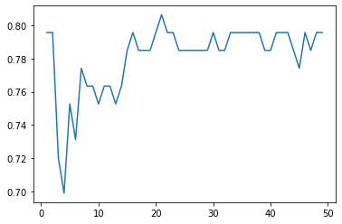

```python
# Automating the task of finding best values of K for KNN

scores =[]
for k in range(1,50):
    NNH = KNeighborsClassifier(n_neighbors = k, weights = 'distance' )
    NNH.fit(X_train, y_train)
    scores.append(NNH.score(X_test, y_test))

plt.plot(range(1,50),scores)
```

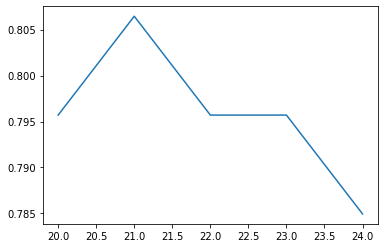

```python
scores =[]
for k in range(20,25):
    NNH = KNeighborsClassifier(n_neighbors = k, weights = 'distance' )
    NNH.fit(X_train, y_train)
    scores.append(NNH.score(X_test, y_test))

plt.plot(range(20,25),scores)
```

```python
NNH = KNeighborsClassifier(n_neighbors = 21 , weights = 'distance' )
```

```python
# Call Nearest Neighbour algorithm

NNH.fit(X_train, y_train)
```

```
KNeighborsClassifier(n_neighbors=21, weights='distance')
```

```python
# Accuracy of training data

predicted_labels = NNH.predict(X_train)
NNH.score(X_train, y_train)
```

```
1.0
```

```python
# Accuracy of testing data

predicted_labels = NNH.predict(X_test)
NNH.score(X_test, y_test)
```

```
0.8064516129032258
```

```
Confusion Matrix
```

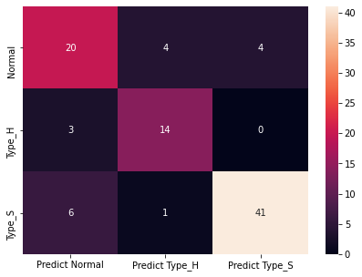

```python
# calculate accuracy measures and confusion matrix. Printing the same as heatmap
from sklearn import metrics

print("Confusion Matrix")
cm=metrics.confusion_matrix(y_test, predicted_labels, labels=['Normal', 'Type_H', 'Type_S'])

df_cm = pd.DataFrame(cm, index = [i for i in ['Normal', 'Type_H', 'Type_S']],
                  columns = [i for i in ['Predict Normal', 'Predict Type_H', 'Predict Type_S']])
plt.figure(figsize = (7,5))
sns.heatmap(df_cm, annot=True)
```

```python
print(classification_report(y_test, predicted_labels))
```

```
              precision    recall  f1-score   support

      Normal       0.69      0.71      0.70        28
      Type_H       0.74      0.82      0.78        17
      Type_S       0.91      0.85      0.88        48

    accuracy                           0.81        93
   macro avg       0.78      0.80      0.79        93
weighted avg       0.81      0.81      0.81        93
```

The precision, recall and f1-score for Normal, Type_H and Type_S classes can be seen in the above classification report

In KNN, the data must be scaled as the model uses a measure of distance. But, just for curiosity, let us try the model with the help of non-scaled data

```python
# Split X and y into training and test set in 70:30 ratio

X_train, X_test, y_train, y_test = train_test_split(X, y, test_size=0.30, random_state=1)
```

```python
NNH = KNeighborsClassifier(n_neighbors=5 , weights = 'distance' )
```

```python
# Call Nearest Neighbour algorithm

NNH.fit(X_train, y_train)
```

```
KNeighborsClassifier(weights='distance')
```

```python
# Accuracy of training data

predicted_labels = NNH.predict(X_train)
NNH.score(X_train, y_train)
```

```
1.0
```

```python
# Accuracy of testing data

predicted_labels = NNH.predict(X_test)
NNH.score(X_test, y_test)
```

```
0.7849462365591398
```

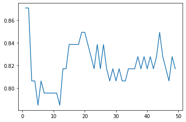

```python
# Automating the task of finding best values of K for KNN

scores =[]
for k in range(1,50):
    NNH = KNeighborsClassifier(n_neighbors = k, weights = 'distance' )
    NNH.fit(X_train, y_train)
    scores.append(NNH.score(X_test, y_test))

plt.plot(range(1,50),scores)
```

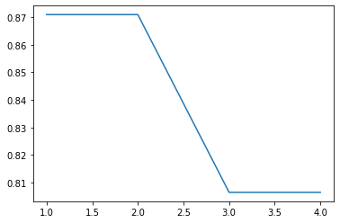

```python
scores =[]
for k in range(1,5):
    NNH = KNeighborsClassifier(n_neighbors = k, weights = 'distance' )
    NNH.fit(X_train, y_train)
    scores.append(NNH.score(X_test, y_test))

plt.plot(range(1,5),scores)
```

```
Confusion Matrix
```

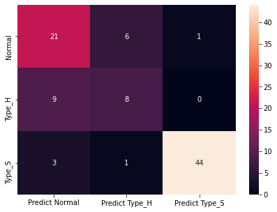

```python
# calculate accuracy measures and confusion matrix. Printing the same as heatmap
from sklearn import metrics

print("Confusion Matrix")
cm=metrics.confusion_matrix(y_test, predicted_labels, labels=['Normal', 'Type_H', 'Type_S'])

df_cm = pd.DataFrame(cm, index = [i for i in ['Normal', 'Type_H', 'Type_S']],
                  columns = [i for i in ['Predict Normal', 'Predict Type_H', 'Predict Type_S']])
plt.figure(figsize = (7,5))
sns.heatmap(df_cm, annot=True)
```

```python
print(classification_report(y_test, predicted_labels))
```

```
              precision    recall  f1-score   support

      Normal       0.64      0.75      0.69        28
      Type_H       0.53      0.47      0.50        17
      Type_S       0.98      0.92      0.95        48

    accuracy                           0.78        93
   macro avg       0.72      0.71      0.71        93
weighted avg       0.79      0.78      0.79        93
```

```python
NNH = KNeighborsClassifier(n_neighbors = 1 , weights = 'distance' )
```

```python
# Call Nearest Neighbour algorithm

NNH.fit(X_train, y_train)
```

```
KNeighborsClassifier(n_neighbors=1, weights='distance')
```

```python
# Accuracy of training data

predicted_labels = NNH.predict(X_train)
NNH.score(X_train, y_train)
```

```
1.0
```

```python
# Accuracy of testing data

predicted_labels = NNH.predict(X_test)
NNH.score(X_test, y_test)
```

```
0.8709677419354839
```

```
Confusion Matrix
```

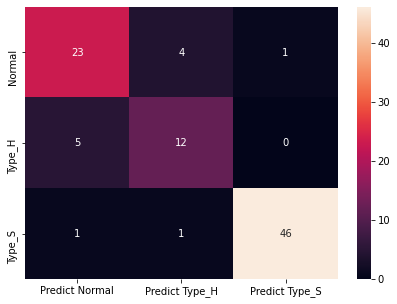

```python
# calculate accuracy measures and confusion matrix. Printing the same as heatmap
from sklearn import metrics

print("Confusion Matrix")
cm=metrics.confusion_matrix(y_test, predicted_labels, labels=['Normal', 'Type_H', 'Type_S'])

df_cm = pd.DataFrame(cm, index = [i for i in ['Normal', 'Type_H', 'Type_S']],
                  columns = [i for i in ['Predict Normal', 'Predict Type_H', 'Predict Type_S']])
plt.figure(figsize = (7,5))
sns.heatmap(df_cm, annot=True)
```

```python
print(classification_report(y_test, predicted_labels))
```

```
              precision    recall  f1-score   support

      Normal       0.79      0.82      0.81        28
      Type_H       0.71      0.71      0.71        17
      Type_S       0.98      0.96      0.97        48

    accuracy                           0.87        93
   macro avg       0.83      0.83      0.83        93
weighted avg       0.87      0.87      0.87        93
```

The precision, recall and f1-score for Normal, Type_H and Type_S classes can be seen in the above classification report

The model with 1 nearest neighbours is showing results that are better than other methods, with accuracy of 87% on the testing data

It is generally not advisable to create model on non-scaled data in case of KNN. But in this exceptional case, this method is showing better results than the one with scaled data

## 6. Conclusion and improvisation:

• Write your conclusion on the results.

• Detailed suggestions or improvements or on quality, quantity, variety, velocity, veracity etc. on the data points collected by the research team to perform a better data analysis in future.

## Conclusion

The model with 1 nearest neighbours without scaling the dataset is showing results that are better than other methods, with accuracy of 87% on the testing data

It is generally not advisable to create model on non-scaled data in case of KNN. But in this exceptional case, this method is showing better results than the one with scaled data

## Suggestions

Larger quantity of data could have helped build a better model with higher accuracy

# Part 2

## 1. Import and warehouse data:

• Import all the given datasets and explore shape and size of each.

• Merge all datasets onto one and explore final shape and size.

```python
#Reading the files

data1 = pd.read_csv('Part2 - Data1.csv')
data2 = pd.read_csv('Part2 -Data2.csv')
```

Checking for null values, shape, size and datatypes

```python
data1.head()
```

|  | ID | Age | CustomerSince | HighestSpend | ZipCode | HiddenScore | MonthlyAverageSpend | Level |
| --- | --- | --- | --- | --- | --- | --- | --- | --- |
| 0 | 1 | 25 | 1 | 49 | 91107 | 4 | 1.6 | 1 |
| 1 | 2 | 45 | 19 | 34 | 90089 | 3 | 1.5 | 1 |
| 2 | 3 | 39 | 15 | 11 | 94720 | 1 | 1.0 | 1 |
| 3 | 4 | 35 | 9 | 100 | 94112 | 1 | 2.7 | 2 |
| 4 | 5 | 35 | 8 | 45 | 91330 | 4 | 1.0 | 2 |

```python
data1.tail()
```

|  | ID | Age | CustomerSince | HighestSpend | ZipCode | HiddenScore | MonthlyAverageSpend | Level |
| --- | --- | --- | --- | --- | --- | --- | --- | --- |
| 4995 | 4996 | 29 | 3 | 40 | 92697 | 1 | 1.9 | 3 |
| 4996 | 4997 | 30 | 4 | 15 | 92037 | 4 | 0.4 | 1 |
| 4997 | 4998 | 63 | 39 | 24 | 93023 | 2 | 0.3 | 3 |
| 4998 | 4999 | 65 | 40 | 49 | 90034 | 3 | 0.5 | 2 |
| 4999 | 5000 | 28 | 4 | 83 | 92612 | 3 | 0.8 | 1 |

```python
data1.isna().sum()
```

```
ID                     0
Age                    0
CustomerSince          0
HighestSpend           0
ZipCode                0
HiddenScore            0
MonthlyAverageSpend    0
Level                  0
dtype: int64
```

```python
data1.shape
```

```
(5000, 8)
```

```python
data1.size
```

```
40000
```

```python
data1.dtypes
```

```
ID                       int64
Age                      int64
CustomerSince            int64
HighestSpend             int64
ZipCode                  int64
HiddenScore              int64
MonthlyAverageSpend    float64
Level                    int64
dtype: object
```

```python
data2.head()
```

|  | ID | Mortgage | Security | FixedDepositAccount | InternetBanking | CreditCard | LoanOnCard |
| --- | --- | --- | --- | --- | --- | --- | --- |
| 0 | 1 | 0 | 1 | 0 | 0 | 0 | NaN |
| 1 | 2 | 0 | 1 | 0 | 0 | 0 | NaN |
| 2 | 3 | 0 | 0 | 0 | 0 | 0 | NaN |
| 3 | 4 | 0 | 0 | 0 | 0 | 0 | NaN |
| 4 | 5 | 0 | 0 | 0 | 0 | 1 | NaN |

```python
data2.tail()
```

|  | ID | Mortgage | Security | FixedDepositAccount | InternetBanking | CreditCard | LoanOnCard |
| --- | --- | --- | --- | --- | --- | --- | --- |
| 4995 | 4996 | 0 | 0 | 0 | 1 | 0 | 0.0 |
| 4996 | 4997 | 85 | 0 | 0 | 1 | 0 | 0.0 |
| 4997 | 4998 | 0 | 0 | 0 | 0 | 0 | 0.0 |
| 4998 | 4999 | 0 | 0 | 0 | 1 | 0 | 0.0 |
| 4999 | 5000 | 0 | 0 | 0 | 1 | 1 | 0.0 |

```python
data2.isna().sum()
```

```
ID                      0
Mortgage                0
Security                0
FixedDepositAccount     0
InternetBanking         0
CreditCard              0
LoanOnCard             20
dtype: int64
```

```python
data2.shape
```

```
(5000, 7)
```

```python
data2.size
```

```
35000
```

```python
data2.dtypes
```

```
ID                       int64
Mortgage                 int64
Security                 int64
FixedDepositAccount      int64
InternetBanking          int64
CreditCard               int64
LoanOnCard             float64
dtype: object
```

```python
data2.columns
```

```
Index(['ID', 'Mortgage', 'Security', 'FixedDepositAccount', 'InternetBanking',
       'CreditCard', 'LoanOnCard'],
      dtype='object')
```

Merging all datasets into one and confirming its shape, size

Printing the first and last 5 rows

```python
df = data1.copy(deep=True)
```

```python
df = df.merge(data2[['ID', 'Mortgage', 'Security', 'FixedDepositAccount', 'InternetBanking','CreditCard', 'LoanOnCard']])
```

```python
df.head()
```

|  | ID | Age | CustomerSince | HighestSpend | ZipCode | HiddenScore | MonthlyAverageSpend | Level | Mortgage | Security | FixedDepositAccount | InternetBanking | CreditCard | LoanOnCard |
| --- | --- | --- | --- | --- | --- | --- | --- | --- | --- | --- | --- | --- | --- | --- |
| 0 | 1 | 25 | 1 | 49 | 91107 | 4 | 1.6 | 1 | 0 | 1 | 0 | 0 | 0 | NaN |
| 1 | 2 | 45 | 19 | 34 | 90089 | 3 | 1.5 | 1 | 0 | 1 | 0 | 0 | 0 | NaN |
| 2 | 3 | 39 | 15 | 11 | 94720 | 1 | 1.0 | 1 | 0 | 0 | 0 | 0 | 0 | NaN |
| 3 | 4 | 35 | 9 | 100 | 94112 | 1 | 2.7 | 2 | 0 | 0 | 0 | 0 | 0 | NaN |
| 4 | 5 | 35 | 8 | 45 | 91330 | 4 | 1.0 | 2 | 0 | 0 | 0 | 0 | 1 | NaN |

```python
df.tail()
```

|  | ID | Age | CustomerSince | HighestSpend | ZipCode | HiddenScore | MonthlyAverageSpend | Level | Mortgage | Security | FixedDepositAccount | InternetBanking | CreditCard | LoanOnCard |
| --- | --- | --- | --- | --- | --- | --- | --- | --- | --- | --- | --- | --- | --- | --- |
| 4995 | 4996 | 29 | 3 | 40 | 92697 | 1 | 1.9 | 3 | 0 | 0 | 0 | 1 | 0 | 0.0 |
| 4996 | 4997 | 30 | 4 | 15 | 92037 | 4 | 0.4 | 1 | 85 | 0 | 0 | 1 | 0 | 0.0 |
| 4997 | 4998 | 63 | 39 | 24 | 93023 | 2 | 0.3 | 3 | 0 | 0 | 0 | 0 | 0 | 0.0 |
| 4998 | 4999 | 65 | 40 | 49 | 90034 | 3 | 0.5 | 2 | 0 | 0 | 0 | 1 | 0 | 0.0 |
| 4999 | 5000 | 28 | 4 | 83 | 92612 | 3 | 0.8 | 1 | 0 | 0 | 0 | 1 | 1 | 0.0 |

```python
df.shape
```

```
(5000, 14)
```

```python
df.size
```

```
70000
```

## 2. Data cleansing:

• Explore and if required correct the datatypes of each attribute

• Explore for null values in the attributes and if required drop or impute values.

Checking for datatypes of merged dataset

Droping columns 'ID' and 'Zipcode' as they don't add value to the analysis

```python
df.dtypes
```

```
ID                       int64
Age                      int64
CustomerSince            int64
HighestSpend             int64
ZipCode                  int64
HiddenScore              int64
MonthlyAverageSpend    float64
Level                    int64
Mortgage                 int64
Security                 int64
FixedDepositAccount      int64
InternetBanking          int64
CreditCard               int64
LoanOnCard             float64
dtype: object
```

```python
df = df.drop(labels= ['ID','ZipCode'] , axis = 1)
```

```python
df.head()
```

|  | Age | CustomerSince | HighestSpend | HiddenScore | MonthlyAverageSpend | Level | Mortgage | Security | FixedDepositAccount | InternetBanking | CreditCard | LoanOnCard |
| --- | --- | --- | --- | --- | --- | --- | --- | --- | --- | --- | --- | --- |
| 0 | 25 | 1 | 49 | 4 | 1.6 | 1 | 0 | 1 | 0 | 0 | 0 | NaN |
| 1 | 45 | 19 | 34 | 3 | 1.5 | 1 | 0 | 1 | 0 | 0 | 0 | NaN |
| 2 | 39 | 15 | 11 | 1 | 1.0 | 1 | 0 | 0 | 0 | 0 | 0 | NaN |
| 3 | 35 | 9 | 100 | 1 | 2.7 | 2 | 0 | 0 | 0 | 0 | 0 | NaN |
| 4 | 35 | 8 | 45 | 4 | 1.0 | 2 | 0 | 0 | 0 | 0 | 1 | NaN |

```python
df.isna().sum()
```

```
Age                     0
CustomerSince           0
HighestSpend            0
HiddenScore             0
MonthlyAverageSpend     0
Level                   0
Mortgage                0
Security                0
FixedDepositAccount     0
InternetBanking         0
CreditCard              0
LoanOnCard             20
dtype: int64
```

Droping the 'na' values as the quantity of data lost is insignificant

```python
df.dropna(inplace=True)
```

```python
df.shape
```

```
(4980, 12)
```

```python
df.dtypes
```

```
Age                      int64
CustomerSince            int64
HighestSpend             int64
HiddenScore              int64
MonthlyAverageSpend    float64
Level                    int64
Mortgage                 int64
Security                 int64
FixedDepositAccount      int64
InternetBanking          int64
CreditCard               int64
LoanOnCard             float64
dtype: object
```

## 3. Data analysis & visualisation:

• Perform detailed statistical analysis on the data.

• Perform a detailed univariate, bivariate and multivariate analysis with appropriate detailed comments after each analysis.

Plotting the frequency distribution of the data variables (excluding outcome column)

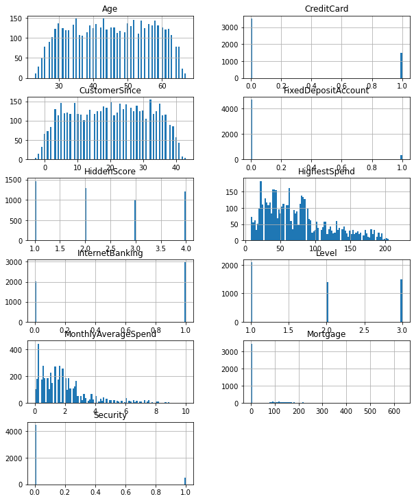

```python
columns = list(df)[0:-1] # Excluding Outcome column
df[columns].hist(stacked=False, bins=100, figsize=(10,30), layout=(14,2));
```

Plotting correlation between the data variables as heatmap

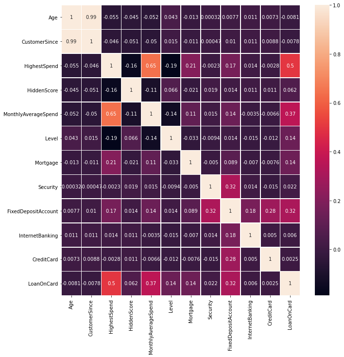

```python
fig, ax = plt.subplots(figsize=(11,11))         # Sample figsize in inches
sns.heatmap(df.corr(),annot=True,linewidths=.5, ax=ax)
```

Pair plot of the data variables gives a better idea of the correlation data

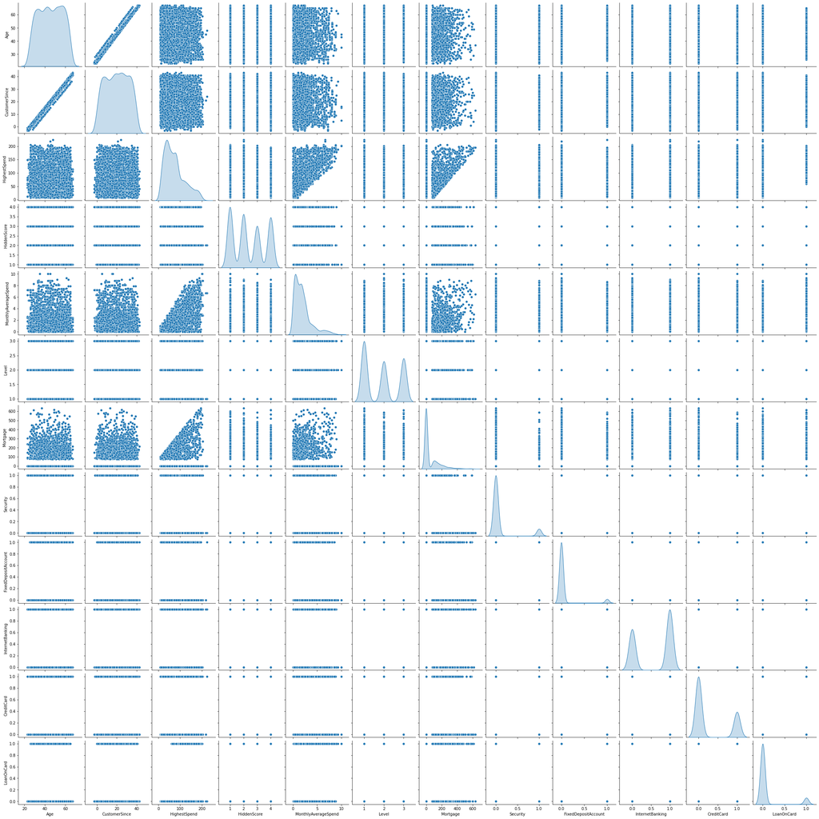

```python
sns.pairplot(df, diag_kind='kde')
```

Checking the % cases of LoanOnCard

```python
n_true = len(df.loc[df['LoanOnCard'] == True])
n_false = len(df.loc[df['LoanOnCard'] == False])
print("Number of true cases (with LoanOnCard): {0} ({1:2.2f}%)".format(n_true, (n_true / (n_true + n_false)) * 100 ))
print("Number of false cases (without LoanOnCard): {0} ({1:2.2f}%)".format(n_false, (n_false / (n_true + n_false)) * 100))
```

```
Number of true cases (with LoanOnCard): 480 (9.64%)
Number of false cases (without LoanOnCard): 4500 (90.36%)
```

Dropping 'Age' as it is having high positive correlation with 'CustomerSince'

```python
df = df.drop(labels= ['Age'] , axis = 1)
```

```python
df.head()
```

|  | CustomerSince | HighestSpend | HiddenScore | MonthlyAverageSpend | Level | Mortgage | Security | FixedDepositAccount | InternetBanking | CreditCard | LoanOnCard |
| --- | --- | --- | --- | --- | --- | --- | --- | --- | --- | --- | --- |
| 9 | 9 | 180 | 1 | 8.9 | 3 | 0 | 0 | 0 | 0 | 0 | 1.0 |
| 10 | 39 | 105 | 4 | 2.4 | 3 | 0 | 0 | 0 | 0 | 0 | 0.0 |
| 11 | 5 | 45 | 3 | 0.1 | 2 | 0 | 0 | 0 | 1 | 0 | 0.0 |
| 12 | 23 | 114 | 2 | 3.8 | 3 | 0 | 1 | 0 | 0 | 0 | 0.0 |
| 13 | 32 | 40 | 4 | 2.5 | 2 | 0 | 0 | 0 | 1 | 0 | 0.0 |

## 4. Data pre-processing:

• Segregate predictors vs target attributes

• Check for target balancing and fix it if found imbalanced.

• Perform train-test split.

```python
df.dtypes
```

```
CustomerSince            int64
HighestSpend             int64
HiddenScore              int64
MonthlyAverageSpend    float64
Level                    int64
Mortgage                 int64
Security                 int64
FixedDepositAccount      int64
InternetBanking          int64
CreditCard               int64
LoanOnCard             float64
dtype: object
```

Segregation of predictors and target variables

```python
from sklearn.model_selection import train_test_split

X = df.drop('LoanOnCard',axis=1)
Y = df['LoanOnCard']   # Predicted variable (1=True, 0=False)
```

Performing train-test split

```python
x_train, x_test, y_train, y_test = train_test_split(X, Y, test_size=0.3, random_state=1)

x_train.head()
```

|  | CustomerSince | HighestSpend | HiddenScore | MonthlyAverageSpend | Level | Mortgage | Security | FixedDepositAccount | InternetBanking | CreditCard |
| --- | --- | --- | --- | --- | --- | --- | --- | --- | --- | --- |
| 1479 | 4 | 43 | 1 | 1.0 | 3 | 102 | 0 | 0 | 0 | 0 |
| 1727 | 26 | 54 | 2 | 1.5 | 2 | 0 | 0 | 0 | 0 | 1 |
| 2843 | 3 | 20 | 4 | 1.0 | 1 | 134 | 0 | 0 | 1 | 1 |
| 4106 | 22 | 54 | 1 | 1.2 | 2 | 0 | 0 | 0 | 0 | 0 |
| 1768 | 18 | 128 | 4 | 5.3 | 1 | 84 | 0 | 0 | 0 | 0 |

Checking the % cases of LoanOnCard on the train-test split

```python
print('True Values  : With LoanOnCard')
print('False Values : Without LoanOnCard')
print('')

print("Original True Values    : {0} ({1:0.2f}%)".format(len(df.loc[df['LoanOnCard'] == 1]), (len(df.loc[df['LoanOnCard'] == 1])/len(df.index)) * 100))
print("Original False Values   : {0} ({1:0.2f}%)".format(len(df.loc[df['LoanOnCard'] == 0]), (len(df.loc[df['LoanOnCard'] == 0])/len(df.index)) * 100))
print("")
print("Training True Values    : {0} ({1:0.2f}%)".format(len(y_train[y_train[:] == 1]), (len(y_train[y_train[:] == 1])/len(y_train)) * 100))
print("Training False Values   : {0} ({1:0.2f}%)".format(len(y_train[y_train[:] == 0]), (len(y_train[y_train[:] == 0])/len(y_train)) * 100))
print("")
print("Test True Values        : {0} ({1:0.2f}%)".format(len(y_test[y_test[:] == 1]), (len(y_test[y_test[:] == 1])/len(y_test)) * 100))
print("Test False Values       : {0} ({1:0.2f}%)".format(len(y_test[y_test[:] == 0]), (len(y_test[y_test[:] == 0])/len(y_test)) * 100))
print("")
```

```
True Values  : With LoanOnCard
False Values : Without LoanOnCard

Original True Values    : 480 (9.64%)
Original False Values   : 4500 (90.36%)

Training True Values    : 327 (9.38%)
Training False Values   : 3159 (90.62%)

Test True Values        : 153 (10.24%)
Test False Values       : 1341 (89.76%)
```

## 5. Model training, testing and tuning:

• Design and train a Logistic regression and Naive Bayes classifiers.

• Display the classification accuracies for train and test data.

• Display and explain the classification report in detail.

• Apply all the possible tuning techniques to train the best model for the given data. Select the final best trained model with your comments for selecting this model.

```python
from sklearn import metrics

from sklearn.linear_model import LogisticRegression

# Fit the model on train
model = LogisticRegression(solver="liblinear")
model.fit(x_train, y_train)

#predict on test
y_predict = model.predict(x_test)
```

```python
model_score = model.score(x_test, y_test)
print(model_score)
```

```
0.9451137884872824
```

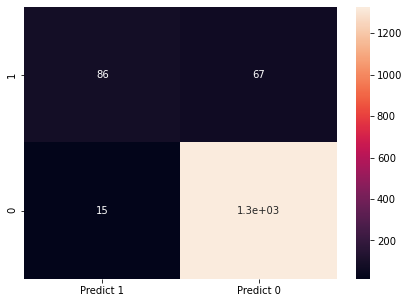

```python
cm=metrics.confusion_matrix(y_test, y_predict, labels=[1, 0])

df_cm = pd.DataFrame(cm, index = [i for i in ["1","0"]],
                  columns = [i for i in ["Predict 1","Predict 0"]])
plt.figure(figsize = (7,5))
sns.heatmap(df_cm, annot=True)
```

```python
print(classification_report(y_test, y_predict))
```

```
              precision    recall  f1-score   support

         0.0       0.95      0.99      0.97      1341
         1.0       0.85      0.56      0.68       153

    accuracy                           0.95      1494
   macro avg       0.90      0.78      0.82      1494
weighted avg       0.94      0.95      0.94      1494
```

LogisticRegression(solver="liblinear") has accuracy of 95%

```python
from sklearn.naive_bayes import GaussianNB # using Gaussian algorithm from Naive Bayes

# create the model
NB_model = GaussianNB()

NB_model.fit(x_train, y_train.ravel())
```

```
GaussianNB()
```

```python
NB_train_predict = NB_model.predict(x_train)

from sklearn import metrics

print("Model Accuracy: {0:.4f}".format(metrics.accuracy_score(y_train, NB_train_predict)))
print()
```

```
Model Accuracy: 0.8867
```

```python
NB_test_predict = NB_model.predict(x_test)

from sklearn import metrics

print("Model Accuracy: {0:.4f}".format(metrics.accuracy_score(y_test, NB_test_predict)))
print()
```

```
Model Accuracy: 0.8809
```

```
Confusion Matrix
```

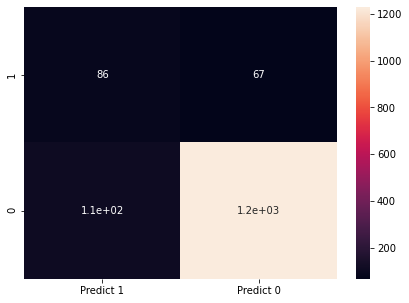

```python
print("Confusion Matrix")
cm=metrics.confusion_matrix(y_test, NB_test_predict, labels=[1, 0])

df_cm = pd.DataFrame(cm, index = [i for i in ["1","0"]],
                  columns = [i for i in ["Predict 1","Predict 0"]])
plt.figure(figsize = (7,5))
sns.heatmap(df_cm, annot=True)
```

```python
print("Classification Report")
print(metrics.classification_report(y_test, NB_test_predict, labels=[1, 0]))
```

```
Classification Report
              precision    recall  f1-score   support

           1       0.44      0.56      0.49       153
           0       0.95      0.92      0.93      1341

    accuracy                           0.88      1494
   macro avg       0.69      0.74      0.71      1494
weighted avg       0.90      0.88      0.89      1494
```

GaussianNB() has accuracy of just 88%

```python
from sklearn import metrics

from sklearn.linear_model import LogisticRegression

# Fit the model on train
model = LogisticRegression(solver="liblinear", penalty='l1')
model.fit(x_train, y_train)

#predict on test
y_predict = model.predict(x_test)
```

```python
model_score = model.score(x_test, y_test)
print(model_score)
```

```
0.9504685408299867
```

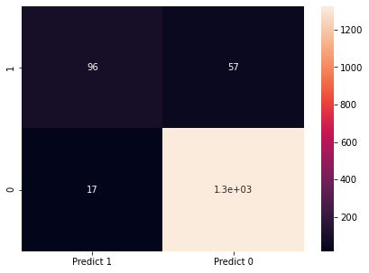

```python
cm=metrics.confusion_matrix(y_test, y_predict, labels=[1, 0])

df_cm = pd.DataFrame(cm, index = [i for i in ["1","0"]],
                  columns = [i for i in ["Predict 1","Predict 0"]])
plt.figure(figsize = (7,5))
sns.heatmap(df_cm, annot=True)
```

```python
print(classification_report(y_test, y_predict))
```

```
              precision    recall  f1-score   support

         0.0       0.96      0.99      0.97      1341
         1.0       0.85      0.63      0.72       153

    accuracy                           0.95      1494
   macro avg       0.90      0.81      0.85      1494
weighted avg       0.95      0.95      0.95      1494
```

LogisticRegression(solver="liblinear", penalty='l1') also has accuracy of 95%

```python
from sklearn.naive_bayes import BernoulliNB

NB_model = BernoulliNB()

NB_model.fit(x_train, y_train.ravel())
```

```
BernoulliNB()
```

```python
NB_train_predict = NB_model.predict(x_train)

from sklearn import metrics

print("Model Accuracy: {0:.4f}".format(metrics.accuracy_score(y_train, NB_train_predict)))
print()
```

```
Model Accuracy: 0.9045
```

```python
NB_test_predict = NB_model.predict(x_test)

from sklearn import metrics

print("Model Accuracy: {0:.4f}".format(metrics.accuracy_score(y_test, NB_test_predict)))
print()
```

```
Model Accuracy: 0.8929
```

```
Confusion Matrix
```

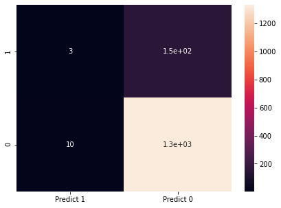

```python
print("Confusion Matrix")
cm=metrics.confusion_matrix(y_test, NB_test_predict, labels=[1, 0])

df_cm = pd.DataFrame(cm, index = [i for i in ["1","0"]],
                  columns = [i for i in ["Predict 1","Predict 0"]])
plt.figure(figsize = (7,5))
sns.heatmap(df_cm, annot=True)
```

```python
print(classification_report(y_test, NB_test_predict))
```

```
              precision    recall  f1-score   support

         0.0       0.90      0.99      0.94      1341
         1.0       0.23      0.02      0.04       153

    accuracy                           0.89      1494
   macro avg       0.56      0.51      0.49      1494
weighted avg       0.83      0.89      0.85      1494
```

BernoulliNB() has accuracy of only 89%

## 6. Conclusion and improvisation:

• Write your conclusion on the results.

• Detailed suggestions or improvements or on quality, quantity, variety, velocity, veracity etc. on the data points collected by the bank to perform a better data analysis in future.

# Conclusion

LogisticRegression(solver="liblinear") or LogisticRegression(solver="liblinear", penalty='l1') can be used in this case for getting best results with an accuracy of 95%

Out of these two models, LogisticRegression(solver="liblinear", penalty='l1') is better as it predicts slightly higher number of true positives which is evident in higher recall and f1-score. But one has to also keep in mind that the number of predicted false positives are also marginally higher.

# Suggestions

No suggestions